# Outline: East Oz Forest Drought

Sami Rifai & …

2020-04-20

```r
# variables to be used inline with the manuscript text
range_map <- tmp$map %>% na.omit() %>% range() %>% round(., -1)
range_pet <- tmp$mapet %>% na.omit() %>% range() %>% round(., -1)
```

## 1. Introduction

- Donohue et al., 2009
- Budyko energy limitation framework
- The rate of climate change in eastern Australia

Questions:  
1. Has meteorological drought severity changed through time?  
2. Have vegetation drought responses changed through time?  
3. Why did forest vegetation respond more to the 2017-2019 drought leading to the “Black Summer” than prior droughts of similar severity?

## 2. Methods

### 2.1 Study region

We focus on eastern Australian vegetation containing trees. Specifically we use the National Vegetation Information System (NVIS) major classes to subset eastern Australia into the focal study regions. These classes are predominantly dominated by trees in the Acacia, Callitris, Casuarina, Eucalyptus, Mallee, Melaleuca genera.

### 2.2 Regional climate

The study region spans a vast gradient in mean annual precipitation (130 - 4140 mm yr^-1) and mean annual potential evapotranspiration (670 - 2100 mm yr^-1).  
NVIS Major Vegetation Classes that contain trees.

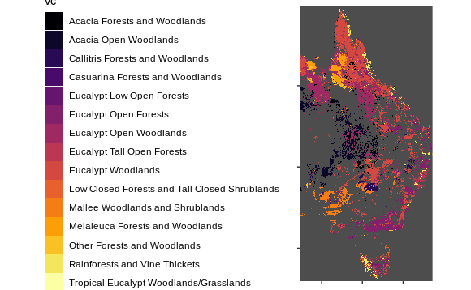

## 3. Results

Question 1: Has meteorological drought severity changed through time?  
Question 2: Have vegetation drought responses changed through time?  
Question 3: Why did forest vegetation respond more to the 2017-2019 drought leading to the “Black Summer” than prior droughts of similar severity?

## 4. Discussion